# Using Models 2

```r
aggregate(body_mass_g ~ species,
          data = penguins,
          FUN = function(x) shapiro.test(x)$p.value)
```

```
##     species body_mass_g
## 1    Adelie  0.03239702
## 2 Chinstrap  0.56050824
## 3    Gentoo  0.23361649
```

Fitting to a Linear Model

```r
fit_species = lm(body_mass_g ~ species, data = penguins)
summary(fit_species)
```

```
##
## Call:
## lm(formula = body_mass_g ~ species, data = penguins)
##
## Residuals:
##      Min       1Q   Median       3Q      Max
## -1126.02  -333.09   -33.09   316.91  1223.98
##
## Coefficients:
##                  Estimate Std. Error t value Pr(>|t|)
## (Intercept)       3700.66      37.62   98.37   <2e-16 ***
## speciesChinstrap    32.43      67.51    0.48    0.631
## speciesGentoo     1375.35      56.15   24.50   <2e-16 ***
## ---
## Signif. codes:  0 '***' 0.001 '**' 0.01 '*' 0.05 '.' 0.1 ' ' 1
##
## Residual standard error: 462.3 on 339 degrees of freedom
##   (2 observations deleted due to missingness)
## Multiple R-squared:  0.6697, Adjusted R-squared:  0.6677
## F-statistic: 343.6 on 2 and 339 DF,  p-value: < 2.2e-16
```

Conducting the ANOVA

```r
anova(fit_species)
```

```
## Analysis of Variance Table
##
## Response: body_mass_g
##            Df    Sum Sq  Mean Sq F value    Pr(>F)
## species     2 146864214 73432107  343.63 < 2.2e-16 ***
## Residuals 339  72443483   213698
## ---
## Signif. codes:  0 '***' 0.001 '**' 0.01 '*' 0.05 '.' 0.1 ' ' 1
```

```r
# Degrees of Freedom: represents the number of levels within a categorical variable
# Sum of Squares: describes the total data variability explained by each predictor variable. Total sum squares measures the total variability.
# Mean Squares: allows for comparing the relative amount of information that each factor explains. (Is the sum sq but adjusted by the DOF)
# F-Statistic/P-Value: Is a measure of how much adding a variable to tehmodel improves the model fit
```

**2-Way Additive ANOVA**

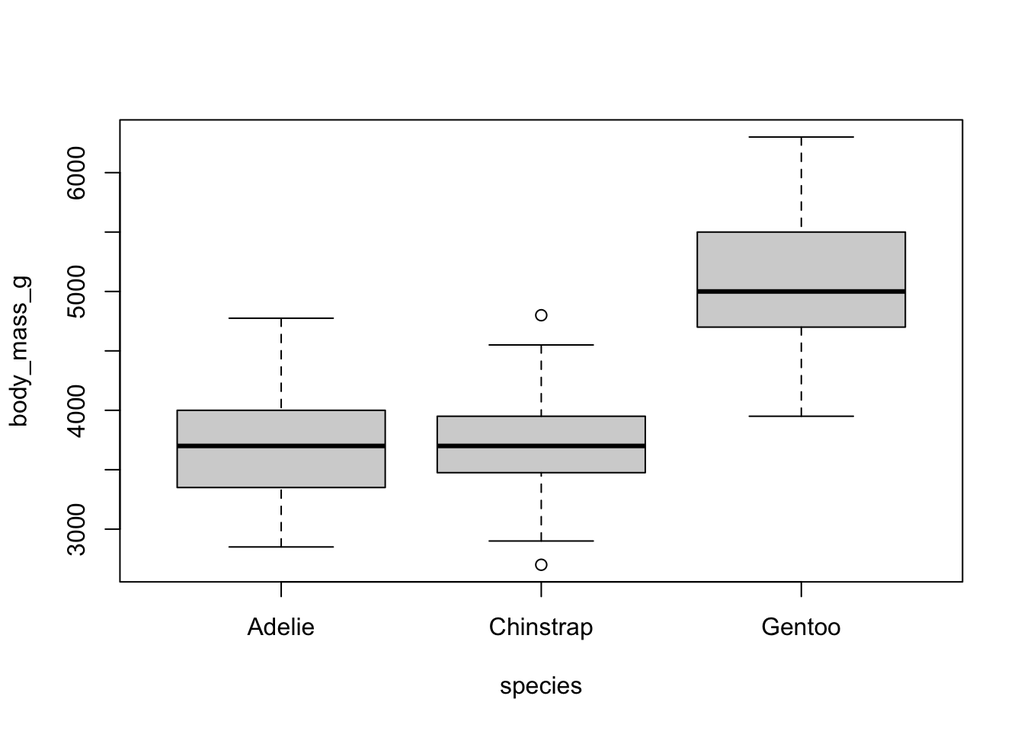

```r
boxplot(body_mass_g ~ species, data = penguins)
```

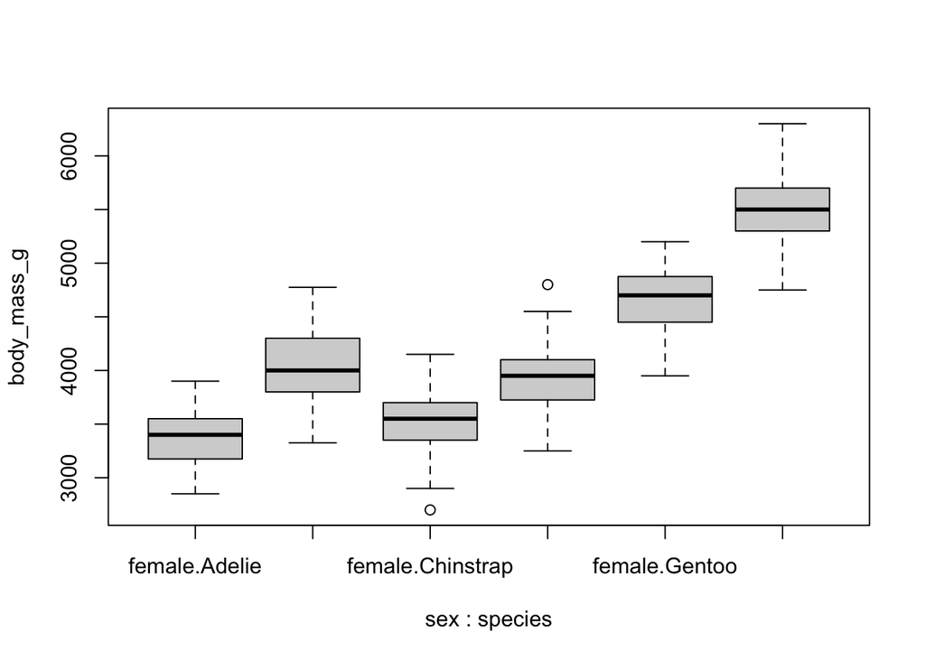

```r
boxplot(body_mass_g ~ sex + species, data = penguins)
```

Fitting a 2-Way Additive ANOVA

```r
fit_additive = lm(body_mass_g ~ sex + species, data = penguins)
summary(fit_additive)
```

```
##
## Call:
## lm(formula = body_mass_g ~ sex + species, data = penguins)
##
## Residuals:
##     Min      1Q  Median      3Q     Max
## -816.87 -217.80  -16.87  227.61  882.20
##
## Coefficients:
##                  Estimate Std. Error t value Pr(>|t|)
## (Intercept)       3372.39      31.43 107.308   <2e-16 ***
## sexmale            667.56      34.70  19.236   <2e-16 ***
## speciesChinstrap    26.92      46.48   0.579    0.563
## speciesGentoo     1377.86      39.10  35.236   <2e-16 ***
## ---
## Signif. codes:  0 '***' 0.001 '**' 0.01 '*' 0.05 '.' 0.1 ' ' 1
##
## Residual standard error: 316.6 on 329 degrees of freedom
##   (11 observations deleted due to missingness)
## Multiple R-squared:  0.8468, Adjusted R-squared:  0.8454
## F-statistic: 606.1 on 3 and 329 DF,  p-value: < 2.2e-16
```

```r
anova(fit_additive)
```

```
## Analysis of Variance Table
##
## Response: body_mass_g
##            Df    Sum Sq  Mean Sq F value    Pr(>F)
## sex         1  38878897 38878897  387.86 < 2.2e-16 ***
## species     2 143401584 71700792  715.29 < 2.2e-16 ***
## Residuals 329  32979185   100241
## ---
## Signif. codes:  0 '***' 0.001 '**' 0.01 '*' 0.05 '.' 0.1 ' ' 1
```

**2-Way Interactive(Factorial) ANOVA**

```r
fit_interactive = lm(body_mass_g ~ sex * species, data = penguins)
summary(fit_interactive)
```

```
##
## Call:
## lm(formula = body_mass_g ~ sex * species, data = penguins)
##
## Residuals:
##     Min      1Q  Median      3Q     Max
## -827.21 -213.97   11.03  206.51  861.03
##
## Coefficients:
##                          Estimate Std. Error t value Pr(>|t|)
## (Intercept)               3368.84      36.21  93.030  < 2e-16 ***
## sexmale                    674.66      51.21  13.174  < 2e-16 ***
## speciesChinstrap           158.37      64.24   2.465  0.01420 *
## speciesGentoo             1310.91      54.42  24.088  < 2e-16 ***
## sexmale:speciesChinstrap  -262.89      90.85  -2.894  0.00406 **
## sexmale:speciesGentoo      130.44      76.44   1.706  0.08886 .
## ---
## Signif. codes:  0 '***' 0.001 '**' 0.01 '*' 0.05 '.' 0.1 ' ' 1
##
## Residual standard error: 309.4 on 327 degrees of freedom
##   (11 observations deleted due to missingness)
## Multiple R-squared:  0.8546, Adjusted R-squared:  0.8524
## F-statistic: 384.3 on 5 and 327 DF,  p-value: < 2.2e-16
```

```r
anova(fit_interactive)
```

```
## Analysis of Variance Table
##
## Response: body_mass_g
##              Df    Sum Sq  Mean Sq F value    Pr(>F)
## sex           1  38878897 38878897 406.145 < 2.2e-16 ***
## species       2 143401584 71700792 749.016 < 2.2e-16 ***
## sex:species   2   1676557   838278   8.757 0.0001973 ***
## Residuals   327  31302628    95727
## ---
## Signif. codes:  0 '***' 0.001 '**' 0.01 '*' 0.05 '.' 0.1 ' ' 1
```

**Simple Linear Regression: Penguin Bills and Body Mass**

```r
lm(bill_length_mm ~ body_mass_g, data = penguins)
```

```
##
## Call:
## lm(formula = bill_length_mm ~ body_mass_g, data = penguins)
##
## Coefficients:
## (Intercept)  body_mass_g
##   26.898872     0.004051
```

## Questions 1 - 3

**1. Re-create the conditional boxplot of penguin body mass conditioned on sex and species. Include your boxplot as a figure in your report**

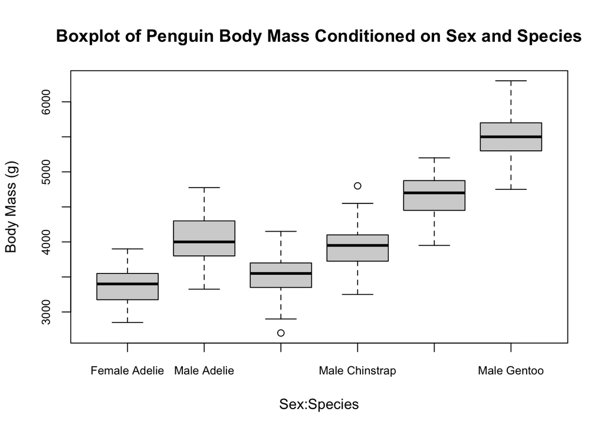

```r
penguin_names = c("Female Adelie", "Male Adelie", "Female Chinstrap", "Male Chinstrap", "Female Gentoo", "Male Gentoo")
boxplot(body_mass_g ~ sex + species,
        data = penguins,
        names = penguin_names,
        main = "Boxplot of Penguin Body Mass Conditioned on Sex and Species",
        xlab = "Sex:Species",
        ylab = "Body Mass (g)",
        cex.axis = 0.8)
```

**2. Based on the boxplots, do you think male penguins are significantly heavier than female penguins of the same species? Explain your reasoning, and be sure to explain why you think any observed differences are significant or not.** Just based on the boxplots, I think there is at least a significant difference in the male and female weights of the Gentoo and Adelie penguins since there is no overlap between their interquartile ranges.

**3. Do you think adding sex to a model that already includes species will improve the model fit?** Based on the boxplots, adding sex does improve the model fit since it is not a complex parameter and it gives insight towards more specific trends in the data.

## Questions 4 - 5

**4. Show the R-code you used to build fit_both**

```r
fit_both = lm(body_mass_g ~ sex * species, data = penguins)
```

**5. What is the base case for the 2-way model that includes sex and species?** The base case is 3368.84, which describes the y-intercept

## Questions 6 - 8

```r
summary(fit_both)
```

```
##
## Call:
## lm(formula = body_mass_g ~ sex * species, data = penguins)
##
## Residuals:
##     Min      1Q  Median      3Q     Max
## -827.21 -213.97   11.03  206.51  861.03
##
## Coefficients:
##                          Estimate Std. Error t value Pr(>|t|)
## (Intercept)               3368.84      36.21  93.030  < 2e-16 ***
## sexmale                    674.66      51.21  13.174  < 2e-16 ***
## speciesChinstrap           158.37      64.24   2.465  0.01420 *
## speciesGentoo             1310.91      54.42  24.088  < 2e-16 ***
## sexmale:speciesChinstrap  -262.89      90.85  -2.894  0.00406 **
## sexmale:speciesGentoo      130.44      76.44   1.706  0.08886 .
## ---
## Signif. codes:  0 '***' 0.001 '**' 0.01 '*' 0.05 '.' 0.1 ' ' 1
##
## Residual standard error: 309.4 on 327 degrees of freedom
##   (11 observations deleted due to missingness)
## Multiple R-squared:  0.8546, Adjusted R-squared:  0.8524
## F-statistic: 384.3 on 5 and 327 DF,  p-value: < 2.2e-16
```

**6. What are the names of the two coefficients (from the first column of the coefficient table) that you need to calculate the average mass of female Chinstrap penguins?** You will need the Intercept and speciesChinstrap

**8. What is the observed average mass of female Chinstrap penguins, calculated from the penguins data?**

```r
penguins_f = droplevels(subset(penguins, sex == "female"))
penguins_f_chin = droplevels(subset(penguins_f, species == "Chinstrap"))
mean(penguins_f_chin$body_mass_g)
```

```
## [1] 3527.206
```